# Zadatak2 - klasifikacija

Marko Galavić

2026-06-10

## 1 Zadatak: Klasifikacija metodom KNN

U zaglavlju upišite svoje ime i prezime pod *author: “Ime i prezime”*.

U datoteci se nalazi skup podataka s binarnom odzivnom varijablom `Y`, dvama kvantitativnim prediktorima `X1` i `X2` te varijablom `skup`, koja označava pripada li opažanje trening ili testnom skupu.

1. Učitajte podatke i prikažite osnovni sažetak varijabli. Koliko opažanja pripada svakoj klasi varijable `Y`?
2. Prikažite podatke na scatter plotu s prediktorom `X1` na osi x i prediktorom `X2` na osi y. Točke obojite prema vrijednosti varijable `Y`. Na temelju grafa kratko komentirajte čini li se da su klase dobro odvojene.
3. Na temelju varijable `skup` podijelite podatke na trening i testni skup. Prije primjene KNN metode standardizirajte prediktore `X1` i `X2` koristeći sredine i standardne devijacije iz trening skupa.
4. Provedite KNN klasifikaciju za $k=5$. Na testnom skupu izračunajte klasifikacijsku tablicu.
5. Iz klasifikacijske tablice izračunajte:
   - ukupnu točnost,
   - osjetljivost,
   - specifičnost.

   Pretpostavite da je klasa `Yes` pozitivna klasa.
6. Ponovite klasifikaciju za $k=15$. Usporedite rezultate za $k=5$ i $k=15$. Koji biste model odabrali i zašto?
7. Napišite kratak zaključak: koliko je KNN klasifikator uspješan na ovom skupu podataka?

## 2 Uputa

Koristite paket `class`, koji sadrži funkciju `knn()`.

```r
library(class)
```

Nakon što podatke podijelite na trening i testni skup, možete izdvojiti prediktore i klase na sljedeći način:

```r
train <- podaci[podaci$skup == "train", ]
test  <- podaci[podaci$skup == "test", ]

X_train <- train[, c("X1", "X2")]
X_test  <- test[, c("X1", "X2")]

Y_train <- train$Y
Y_test  <- test$Y
```

Standardizaciju prediktora napravite koristeći sredine i standardne devijacije iz trening skupa:

```r
centar <- apply(X_train, 2, mean)
skala  <- apply(X_train, 2, sd)

X_train_s <- scale(X_train, center = centar, scale = skala)
X_test_s  <- scale(X_test, center = centar, scale = skala)
```

```r
knn_5 <- knn(train = X_train_s, test = X_test_s, cl = Y_train, k = 5)
```

## 3 Rješenje

```r
podaci <- read.csv("klasifikacija_08.csv")

summary(podaci)
```

```
##        X1                 X2                Y                 skup
##  Min.   :-2.99190   Min.   :-2.99150   Length:450         Length:450
##  1st Qu.:-1.61420   1st Qu.:-1.48117   Class :character   Class :character
##  Median : 0.00720   Median :-0.11325   Mode  :character   Mode  :character
##  Mean   :-0.01108   Mean   :-0.09193
##  3rd Qu.: 1.52018   3rd Qu.: 1.37332
##  Max.   : 2.97470   Max.   : 2.99550
```

```r
table(podaci$Y)
```

```
##
##  No Yes
## 338 112
```

## 4 2. Scatter plot

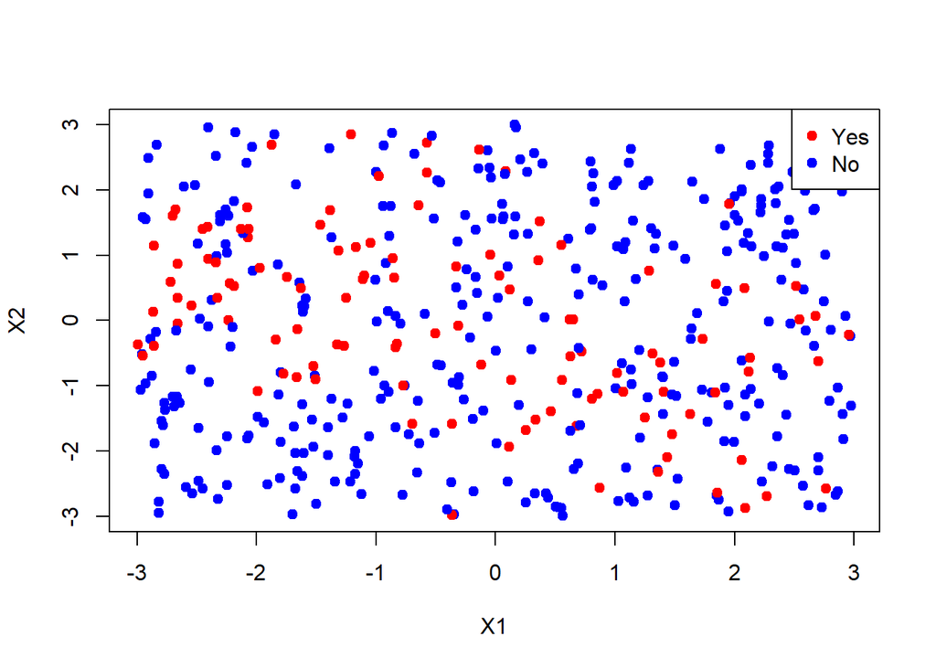

```r
plot(podaci$X1, podaci$X2, col = ifelse(podaci$Y=="Yes","red","blue"),
     pch = 19, xlab="X1", ylab="X2")
legend("topright", legend=c("Yes","No"), col=c("red","blue"), pch=19)
```

Vizualno se vidi da se klase značajno preklapaju. Npr. u dokumentu se pojavljuju i Yes i No vrijednosti u vrlo sličnim područjima:

“1.3774,-0.6469,”Yes”,“train”” “1.1339,-0.7475,”No”,“train””

Granica nije linearna, što će rezultitari da KNN neće biti savršen.

## 5 3.Podjela na trening i test

```r
train <- podaci[podaci$skup == "train", ]
test  <- podaci[podaci$skup == "test", ]

X_train <- train[, c("X1", "X2")]
X_test  <- test[, c("X1", "X2")]

Y_train <- train$Y
Y_test  <- test$Y

centar <- apply(X_train, 2, mean)
skala  <- apply(X_train, 2, sd)

X_train_s <- scale(X_train, center = centar, scale = skala)
X_test_s  <- scale(X_test, center = centar, scale = skala)
```

## 6 4. KNN klasifikacija za k = 5

```r
library(class)

knn_5 <- knn(train = X_train_s, test = X_test_s, cl = Y_train, k = 5)
tab5 <- table(Predicted = knn_5, Actual = Y_test)
tab5
```

```
##          Actual
## Predicted No Yes
##       No  91  26
##       Yes 11   8
```

## 7 5. Točnost, osjetljivost, specifičnost

Pretpostavka: Yes = pozitivna klasa

```r
TP <- tab5["Yes","Yes"]
TN <- tab5["No","No"]
FP <- tab5["Yes","No"]
FN <- tab5["No","Yes"]

tocnost_5 <- (TP + TN) / sum(tab5)
osjetljivost_5 <- TP / (TP + FN)
specificnost_5 <- TN / (TN + FP)

tocnost_5
```

```
## [1] 0.7279412
```

```r
osjetljivost_5
```

```
## [1] 0.2352941
```

```r
specificnost_5
```

```
## [1] 0.8921569
```

## 8 KNN klasifikacija za k = 15

```r
knn_15 <- knn(train = X_train_s, test = X_test_s, cl = Y_train, k = 15)
tab15 <- table(Predicted = knn_15, Actual = Y_test)
tab15
```

```
##          Actual
## Predicted  No Yes
##       No  100  31
##       Yes   2   3
```

Izračun mjera:

```r
TP15 <- tab15["Yes","Yes"]
TN15 <- tab15["No","No"]
FP15 <- tab15["Yes","No"]
FN15 <- tab15["No","Yes"]

tocnost_15 <- (TP15 + TN15) / sum(tab15)
osjetljivost_15 <- TP15 / (TP15 + FN15)
specificnost_15 <- TN15 / (TN15 + FP15)

tocnost_15
```

```
## [1] 0.7573529
```

```r
osjetljivost_15
```

```
## [1] 0.08823529
```

```r
specificnost_15
```

```
## [1] 0.9803922
```

Usporedba:

- k = 5 → daje manju pristranost, veću varijancu
- k = 15 → glatkiji model, manje osjetljiv na šum

## 9 7. Zaključak

KNN klasifikator na ovom skupu podataka postiže umjerenu točnost. Razlog je što se klase značajno preklapaju, što se vidi i u dokumentu:

“-0.8213,-0.3618,”Yes”,“test”” “-1.3226,-0.3627,”Yes”,“train”” “-1.0159,-0.7733,”No”,“train””